# Required

The required libraries/packages for this assignment is `pandas` ,`matplotlib` and `seaborn`.

- `pip install pandas`
- `pip instal matplotlib`
- `pip install seaborn`

## Read in the "Urban Park Rangers" dataset

Read the required data from the CSV file and inspect it.

```python
import pandas as pd
import warnings
warnings.filterwarnings('ignore')

#Loading the dataset
df = pd.read_csv("/content/Urban_Park_Ranger_Animal_Condition_Response.csv")
```

```python
#Inspect the first 5 rows of the dataset

df.head()
```

|  | Date and Time of initial call | Date and time of Ranger response | Borough | Property | Location | Species Description | Call Source | Species Status | Animal Condition | Duration of Response | ... | 311SR Number | Final Ranger Action | # of Animals | PEP Response | Animal Monitored | Rehabilitator | Hours spent monitoring | Police Response | ESU Response | ACC Intake Number |
| --- | --- | --- | --- | --- | --- | --- | --- | --- | --- | --- | --- | --- | --- | --- | --- | --- | --- | --- | --- | --- | --- |
| 0 | 06/23/2021 04:45:00 PM | 06/24/2021 08:00:00 AM | Brooklyn | Sternberg Park | Inside locked athletic field under construction | Chukar | Other | Exotic | Healthy | 6.00 | ... | 311-06712416 | ACC | 6.0 | False | False | NaN | NaN | False | False | 163537 |
| 1 | 06/24/2021 10:00:00 AM | 06/24/2021 11:00:00 AM | Bronx | Haffen Park | Haffen Pool | Sparrow | Central | Native | Healthy | 1.75 | ... | 311-06714879 | Rehabilitator | 4.0 | False | False | NaN | NaN | False | False | NaN |
| 2 | 06/23/2021 02:30:00 PM | 06/23/2021 02:30:00 PM | Bronx | Pelham Bay Park | Pelham Bay South | White-tailed Deer | Employee | Native | NaN | 1.00 | ... | NaN | Unfounded | 0.0 | False | False | NaN | NaN | False | False | NaN |
| 3 | 06/23/2021 01:00:00 PM | 06/23/2021 01:10:00 PM | Staten Island | Willowbrook Park | The carousel | Raccoon | Employee | Native | NaN | 2.00 | ... | NaN | Unfounded | 0.0 | False | False | NaN | NaN | False | False | NaN |
| 4 | 06/23/2021 09:20:00 AM | 06/23/2021 09:20:00 AM | Queens | Judge Moses Weinstein Playground | Garbage can | Virginia Opossum | Central | Native | Healthy | 2.25 | ... | 311-06699415 | ACC | 1.0 | False | False | NaN | NaN | False | False | 119833 |

5 rows × 22 columns

```python
#Inspect the last 5 rows of the dataset
df.tail()
```

|  | Date and Time of initial call | Date and time of Ranger response | Borough | Property | Location | Species Description | Call Source | Species Status | Animal Condition | Duration of Response | ... | 311SR Number | Final Ranger Action | # of Animals | PEP Response | Animal Monitored | Rehabilitator | Hours spent monitoring | Police Response | ESU Response | ACC Intake Number |
| --- | --- | --- | --- | --- | --- | --- | --- | --- | --- | --- | --- | --- | --- | --- | --- | --- | --- | --- | --- | --- | --- |
| 2604 | 06/05/2018 12:00:00 AM | 06/05/2018 12:01:00 AM | Manhattan | Abingdon Square | NaN | raccoon | Central | Native | Healthy | 0.75 | ... | NaN | Relocated/Condition Corrected | 1.0 | False | True | NaN | 1.0 | False | False | NaN |
| 2605 | 06/01/2018 12:00:00 PM | 06/01/2018 12:30:00 PM | Manhattan | Central Park | park | Raccoon | Employee | Native | Injured | 1.25 | ... | 1-1-1568786600 | ACC | 1.0 | False | False | NaN | NaN | False | False | 36061 |
| 2606 | 05/16/2018 09:00:00 AM | 05/17/2018 10:10:00 AM | Manhattan | Morningside Park | NaN | Raccoon | Employee | Native | DOA | 1.50 | ... | NaN | ACC | 2.0 | False | True | NaN | 0.5 | False | False | 28316 |
| 2607 | 05/02/2018 09:30:00 AM | 05/02/2018 12:00:00 PM | Manhattan | Central Park | park sewer drain | Raccoon | Public | Native | Healthy | 0.75 | ... | NaN | Unfounded | 0.0 | NaN | NaN | NaN | NaN | NaN | False | NaN |
| 2608 | 05/07/2018 01:30:00 PM | 05/07/2018 01:40:00 PM | Manhattan | Central Park | West Dr and 99th Str | Red-tailed Hawk | Employee | Native | DOA | 1.00 | ... | NaN | Submitted for DEC Testing | 1.0 | False | NaN | NaN | NaN | NaN | False | NaN |

5 rows × 22 columns

## Exploring the data

Understand the total number of rows and columns of the dataset along with the datatypes of each column. Additionally, figure out how many non-null values are present so that I can drop the missing values if they are very few or perform imputation methods if they are many missing values in the filtered dataset

```python
df.info()
```

```
<class 'pandas.core.frame.DataFrame'>
RangeIndex: 2609 entries, 0 to 2608
Data columns (total 22 columns):
 #   Column                            Non-Null Count  Dtype
---  ------                            --------------  -----
 0   Date and Time of initial call     2609 non-null   object
 1   Date and time of Ranger response  2609 non-null   object
 2   Borough                           2609 non-null   object
 3   Property                          2608 non-null   object
 4   Location                          2570 non-null   object
 5   Species Description               2609 non-null   object
 6   Call Source                       2609 non-null   object
 7   Species Status                    2593 non-null   object
 8   Animal Condition                  2219 non-null   object
 9   Duration of Response              2609 non-null   float64
 10  Age                               2609 non-null   object
 11  Animal Class                      2609 non-null   object
 12  311SR Number                      1270 non-null   object
 13  Final Ranger Action               2609 non-null   object
 14  # of Animals                      2605 non-null   float64
 15  PEP Response                      2608 non-null   object
 16  Animal Monitored                  2607 non-null   object
 17  Rehabilitator                     275 non-null    object
 18  Hours spent monitoring            353 non-null    float64
 19  Police Response                   2607 non-null   object
 20  ESU Response                      2609 non-null   bool
 21  ACC Intake Number                 725 non-null    object
dtypes: bool(1), float64(3), object(18)
memory usage: 430.7+ KB
```

## Filtering the dataset

Subset the data by columns to choose only those columns which will help in answering the dataset associated questions.

```python
filtered_df=df.filter(items=['Date and Time of initial call','Call Source','Animal Class','# of Animals','Final Ranger Action'])
```

```python
filtered_df.head(10)
```

|  | Date and Time of initial call | Call Source | Animal Class | # of Animals | Final Ranger Action |
| --- | --- | --- | --- | --- | --- |
| 0 | 06/23/2021 04:45:00 PM | Other | Birds | 6.0 | ACC |
| 1 | 06/24/2021 10:00:00 AM | Central | Birds | 4.0 | Rehabilitator |
| 2 | 06/23/2021 02:30:00 PM | Employee | Deer | 0.0 | Unfounded |
| 3 | 06/23/2021 01:00:00 PM | Employee | Small Mammals-RVS | 0.0 | Unfounded |
| 4 | 06/23/2021 09:20:00 AM | Central | Small Mammals-non RVS | 1.0 | ACC |
| 5 | 06/23/2021 09:00:00 AM | Employee | Domestic;#Birds | 1.0 | ACC |
| 6 | 06/23/2021 05:30:00 AM | Employee | Birds | 0.0 | Unfounded |
| 7 | 06/22/2021 03:00:00 PM | Public | Domestic | 0.0 | Unfounded |
| 8 | 06/22/2021 03:30:00 PM | Employee | Domestic | 1.0 | ACC |
| 9 | 06/22/2021 11:30:00 AM | Central | Domestic | 0.0 | Unfounded |

```python
filtered_df.info()
```

```
<class 'pandas.core.frame.DataFrame'>
RangeIndex: 2609 entries, 0 to 2608
Data columns (total 5 columns):
 #   Column                         Non-Null Count  Dtype
---  ------                         --------------  -----
 0   Date and Time of initial call  2609 non-null   object
 1   Call Source                    2609 non-null   object
 2   Animal Class                   2609 non-null   object
 3   # of Animals                   2605 non-null   float64
 4   Final Ranger Action            2609 non-null   object
dtypes: float64(1), object(4)
memory usage: 102.0+ KB
```

## Datapreprocessing : Data cleaning for the filtered dataset

- Perform data cleaning by changing the datatype of "Date and Time of initial call" from "Object" to "DateTime".
- Column named "Animal Class" contains messy labels with values like (;,#) so in order to keep data consistent and reliable for further analysis, I am replacing the original messy string data by extracting only the label name after # and saving it as new label.

```python
filtered_df['Date and Time of initial call']=pd.to_datetime(filtered_df['Date and Time of initial call'])
```

```python
filtered_df.info()
```

```
<class 'pandas.core.frame.DataFrame'>
RangeIndex: 2609 entries, 0 to 2608
Data columns (total 5 columns):
 #   Column                         Non-Null Count  Dtype
---  ------                         --------------  -----
 0   Date and Time of initial call  2609 non-null   datetime64[ns]
 1   Call Source                    2609 non-null   object
 2   Animal Class                   2609 non-null   object
 3   # of Animals                   2605 non-null   float64
 4   Final Ranger Action            2609 non-null   object
dtypes: datetime64[ns](1), float64(1), object(3)
memory usage: 102.0+ KB
```

```python
# Split the values in the 'Animal Class' column based on the '#' symbol
filtered_df['Animal Class'] = filtered_df['Animal Class'].str.split('#').str[-1]
```

```python
filtered_df.head(10)
```

|  | Date and Time of initial call | Call Source | Animal Class | # of Animals | Final Ranger Action |
| --- | --- | --- | --- | --- | --- |
| 0 | 2021-06-23 16:45:00 | Other | Birds | 6.0 | ACC |
| 1 | 2021-06-24 10:00:00 | Central | Birds | 4.0 | Rehabilitator |
| 2 | 2021-06-23 14:30:00 | Employee | Deer | 0.0 | Unfounded |
| 3 | 2021-06-23 13:00:00 | Employee | Small Mammals-RVS | 0.0 | Unfounded |
| 4 | 2021-06-23 09:20:00 | Central | Small Mammals-non RVS | 1.0 | ACC |
| 5 | 2021-06-23 09:00:00 | Employee | Birds | 1.0 | ACC |
| 6 | 2021-06-23 05:30:00 | Employee | Birds | 0.0 | Unfounded |
| 7 | 2021-06-22 15:00:00 | Public | Domestic | 0.0 | Unfounded |
| 8 | 2021-06-22 15:30:00 | Employee | Domestic | 1.0 | ACC |
| 9 | 2021-06-22 11:30:00 | Central | Domestic | 0.0 | Unfounded |

## Data Manipulation: Adding new column

Adding a new column named "Report_Year" that extracts the year value from "Date and Time of initial call" column so that annual trend can be observed in further data analysis phase.

```python
filtered_df['Report_Year']=filtered_df['Date and Time of initial call'].dt.year
filtered_df
```

|  | Date and Time of initial call | Call Source | Animal Class | # of Animals | Final Ranger Action | Report_Year |
| --- | --- | --- | --- | --- | --- | --- |
| 0 | 2021-06-23 16:45:00 | Other | Birds | 6.0 | ACC | 2021 |
| 1 | 2021-06-24 10:00:00 | Central | Birds | 4.0 | Rehabilitator | 2021 |
| 2 | 2021-06-23 14:30:00 | Employee | Deer | 0.0 | Unfounded | 2021 |
| 3 | 2021-06-23 13:00:00 | Employee | Small Mammals-RVS | 0.0 | Unfounded | 2021 |
| 4 | 2021-06-23 09:20:00 | Central | Small Mammals-non RVS | 1.0 | ACC | 2021 |
| ... | ... | ... | ... | ... | ... | ... |
| 2604 | 2018-06-05 00:00:00 | Central | Small Mammals-RVS | 1.0 | Relocated/Condition Corrected | 2018 |
| 2605 | 2018-06-01 12:00:00 | Employee | Small Mammals-RVS | 1.0 | ACC | 2018 |
| 2606 | 2018-05-16 09:00:00 | Employee | Small Mammals-RVS | 2.0 | ACC | 2018 |
| 2607 | 2018-05-02 09:30:00 | Public | Small Mammals-RVS | 0.0 | Unfounded | 2018 |
| 2608 | 2018-05-07 13:30:00 | Employee | Raptors | 1.0 | Submitted for DEC Testing | 2018 |

2609 rows × 6 columns

## Data Manipulation: Dropping unwanted/unused columns

- Finally, drop the "Date and Time of initial call" column as it does not contribute for further analysis.

```python
filtered_df.drop(columns=['Date and Time of initial call'], inplace=True)
filtered_df
```

|  | Call Source | Animal Class | # of Animals | Final Ranger Action | Report_Year |
| --- | --- | --- | --- | --- | --- |
| 0 | Other | Birds | 6.0 | ACC | 2021 |
| 1 | Central | Birds | 4.0 | Rehabilitator | 2021 |
| 2 | Employee | Deer | 0.0 | Unfounded | 2021 |
| 3 | Employee | Small Mammals-RVS | 0.0 | Unfounded | 2021 |
| 4 | Central | Small Mammals-non RVS | 1.0 | ACC | 2021 |
| ... | ... | ... | ... | ... | ... |
| 2604 | Central | Small Mammals-RVS | 1.0 | Relocated/Condition Corrected | 2018 |
| 2605 | Employee | Small Mammals-RVS | 1.0 | ACC | 2018 |
| 2606 | Employee | Small Mammals-RVS | 2.0 | ACC | 2018 |
| 2607 | Public | Small Mammals-RVS | 0.0 | Unfounded | 2018 |
| 2608 | Employee | Raptors | 1.0 | Submitted for DEC Testing | 2018 |

2609 rows × 5 columns

## Handling Missing Values

```python
#Before storing filtered_df as a sheet in excel file. Checking are there  any missing values.
filtered_df.isna().sum()
```

```
Call Source            0
Animal Class           0
# of Animals           4
Final Ranger Action    0
Report_Year            0
dtype: int64
```

There are 4 missing values in the '# of Animals' column, which is extremely minimal relative to the dataset size, so it is better to drop them.

```python
filtered_df.dropna(subset=['# of Animals'], inplace=True)
filtered_df.info()
```

```
<class 'pandas.core.frame.DataFrame'>
Index: 2605 entries, 0 to 2608
Data columns (total 5 columns):
 #   Column               Non-Null Count  Dtype
---  ------               --------------  -----
 0   Call Source          2605 non-null   object
 1   Animal Class         2605 non-null   object
 2   # of Animals         2605 non-null   float64
 3   Final Ranger Action  2605 non-null   object
 4   Report_Year          2605 non-null   int32
dtypes: float64(1), int32(1), object(3)
memory usage: 111.9+ KB
```

## Data Storage in a new excel file

Storing the filtered dataframe in the new excel file named "Pooja_Output_File.xlsx" and sheet named "Importable Table"

```python
# Specify the Excel file name and sheet name
excel_file = 'Pooja_Output_File.xlsx'
sheet_name = 'Importable table'

# Save DataFrame to Excel file with the specified sheet name
filtered_df.to_excel(excel_file, sheet_name=sheet_name, index=False)
```

## Load the dataset and write code to answer questions.

Read in the "Importable Table" dataset. Read the required data from the specific sheet of the excel file and inspect it.

```python
final_df=pd.read_excel('Pooja_Output_File.xlsx',sheet_name='Importable table')
```

```python
final_df.head()
```

|  | Call Source | Animal Class | # of Animals | Final Ranger Action | Report_Year |
| --- | --- | --- | --- | --- | --- |
| 0 | Other | Birds | 6 | ACC | 2021 |
| 1 | Central | Birds | 4 | Rehabilitator | 2021 |
| 2 | Employee | Deer | 0 | Unfounded | 2021 |
| 3 | Employee | Small Mammals-RVS | 0 | Unfounded | 2021 |
| 4 | Central | Small Mammals-non RVS | 1 | ACC | 2021 |

```python
final_df.info()
```

```
<class 'pandas.core.frame.DataFrame'>
RangeIndex: 2605 entries, 0 to 2604
Data columns (total 5 columns):
 #   Column               Non-Null Count  Dtype
---  ------               --------------  -----
 0   Call Source          2605 non-null   object
 1   Animal Class         2605 non-null   object
 2   # of Animals         2605 non-null   int64
 3   Final Ranger Action  2605 non-null   object
 4   Report_Year          2605 non-null   int64
dtypes: int64(2), object(3)
memory usage: 101.9+ KB
```

Changing the column named 'Report_Year' from 'int64' datatype to 'Object' datatype as it is categorical in nature.

```python
final_df['Report_Year']=final_df['Report_Year'].astype('object')
final_df.info()
```

```
<class 'pandas.core.frame.DataFrame'>
RangeIndex: 2605 entries, 0 to 2604
Data columns (total 5 columns):
 #   Column               Non-Null Count  Dtype
---  ------               --------------  -----
 0   Call Source          2605 non-null   object
 1   Animal Class         2605 non-null   object
 2   # of Animals         2605 non-null   int64
 3   Final Ranger Action  2605 non-null   object
 4   Report_Year          2605 non-null   object
dtypes: int64(1), object(4)
memory usage: 101.9+ KB
```

## Data Manipulation: Grouping and Aggregating

Let's answer the the questions:

## Question 1:

How has the number of animals sent to rehabilitators or animal care centres changed over time?

```python
# Creating a dataframe that holds only information for animals sent to rehabilitators or animal care centres.
rehab_or_acc=final_df[(final_df['Final Ranger Action']=='Rehabilitator') | (final_df['Final Ranger Action']=='ACC')]
rehab_or_acc
```

|  | Call Source | Animal Class | # of Animals | Final Ranger Action | Report_Year |
| --- | --- | --- | --- | --- | --- |
| 0 | Other | Birds | 6 | ACC | 2021 |
| 1 | Central | Birds | 4 | Rehabilitator | 2021 |
| 4 | Central | Small Mammals-non RVS | 1 | ACC | 2021 |
| 5 | Employee | Birds | 1 | ACC | 2021 |
| 8 | Employee | Domestic | 1 | ACC | 2021 |
| ... | ... | ... | ... | ... | ... |
| 2597 | Public | Raptors | 1 | Rehabilitator | 2018 |
| 2598 | Conservancies/"Friends of" Groups | Small Mammals-RVS | 1 | ACC | 2018 |
| 2599 | Public | Raptors | 1 | Rehabilitator | 2018 |
| 2601 | Employee | Small Mammals-RVS | 1 | ACC | 2018 |
| 2602 | Employee | Small Mammals-RVS | 2 | ACC | 2018 |

1057 rows × 5 columns

```python
# Computing the number of animals for each year to understand the annual trend.
no_of_animals_over_time=rehab_or_acc.groupby('Report_Year')['# of Animals'].sum().reset_index()
no_of_animals_over_time
```

|  | Report_Year | # of Animals |
| --- | --- | --- |
| 0 | 2018 | 390 |
| 1 | 2019 | 290 |
| 2 | 2020 | 370 |
| 3 | 2021 | 208 |

```python
# Pivot table for number of animal sent to rehabilitators or animal care centers per year
animal_count_over_time=rehab_or_acc.groupby(['Report_Year','Final Ranger Action'])['# of Animals'].sum().reset_index(name='Animal_Count')
no_of_animals_pivot_table = animal_count_over_time.pivot(index='Final Ranger Action', columns='Report_Year', values='Animal_Count')

# Calculate the total per year
total_per_year = no_of_animals_pivot_table.sum(axis=0)

# Append the total as a new row
no_of_animals_pivot_table.loc['Total'] = total_per_year
no_of_animals_pivot_table

# Define a function to highlight the total row and index
def highlight_total(s):
    is_total = s.name == 'Total'
    return ['background-color: yellow' if is_total else '' for _ in s]

# Define a function to highlight the total index
def highlight_total_index(idx):
    return ['background-color: yellow' if idx == 'Total' else '' for _ in idx]

# Style the DataFrame
styled_table = no_of_animals_pivot_table.style.apply(highlight_total, axis=1)\
                                             .apply(lambda x: ['background-color: yellow' if x.name == 'Total' else '' for _ in x], axis=1)\
                                             .set_table_styles({'Total': [{'selector': 'th', 'props': [('background-color', 'yellow')]}]}, axis=1)

# Display the styled DataFrame
styled_table
```

| Report_Year Final Ranger Action | 2018 | 2019 | 2020 | 2021 |
| --- | --- | --- | --- | --- |
| ACC | 345 | 212 | 219 | 133 |
| Rehabilitator | 45 | 78 | 151 | 75 |
| Total | 390 | 290 | 370 | 208 |

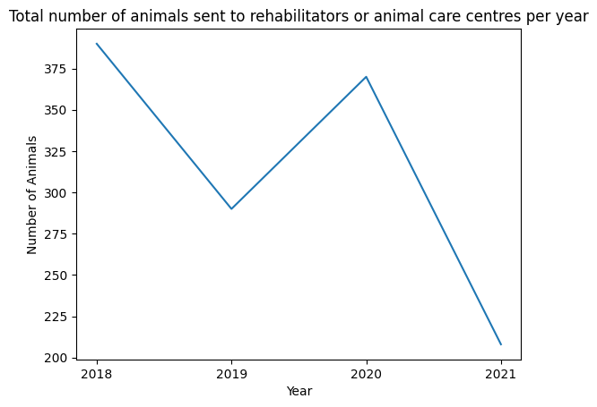

```python
import matplotlib.pyplot as plt
import seaborn as sns
rehab_or_acc.groupby('Report_Year')['# of Animals'].sum().plot().set_xticks(range(int(rehab_or_acc['Report_Year'].min()), int(rehab_or_acc['Report_Year'].max()) + 1))
plt.title("Total number of animals sent to rehabilitators or animal care centres per year")
plt.xlabel('Year')
plt.ylabel('Number of Animals')
plt.show()
```

## Key Observations:

The lineplot titled "Total number of animals sent to rehabilitators or animal care centres per year" shows the annual trend of animals sent to rehabilitators or care centers from 2018 to 2021.

- **Decrease from 2018 to 2019:**
  - In 2018, the number of animals sent to rehabilitators or animal care centres was at its peak more than 375 animals.
  - In 2019, there was a significant decrease, dropping to 290 animals.
- **Increase from 2019 to 2020:**
  - In 2020, there was a recovery and an increase in the number of animals sent, rising back to 370 animals. This suggests that some factors may have led to more animals being reported or needing care compared to the previous year.
- **Sharp Decline from 2020 to 2021:**
  - The most noticeable change is the sharp decline from 2020 to 2021, where the number dropped to around 200 animals. This is a significant reduction and the lowest number in the observed period.

Although the dataset does not explain what resulted in the significant decline of total number of animals reported annually, as per my subjective opinion/assumptions(no factual proof or data inference), major possibilities could be external factors like environmental changes that influenced wildlife population or the COVID-19 pandemic during 2020 and 2021 likely affected the operations of rehabilitators and care centres. Strong factual observation about this is not available due to insufficient data pertaining to factors affecting this issue.

**Conclusion:** The lineplot highlights significant fluctuations, particularly the sharp decline in 2021, warranting further investigation. Understanding these trends is crucial for effective wildlife management and resource allocation.

## Question 2

How has the type of animal being reported changed over time?

```python
animal_class_over_time=final_df.groupby(['Report_Year','Animal Class']).size().reset_index(name='Animal_Count')
animal_class_over_time
```

|  | Report_Year | Animal Class | Animal_Count |
| --- | --- | --- | --- |
| 0 | 2018 | Birds | 105 |
| 1 | 2018 | Coyotes | 2 |
| 2 | 2018 | Deer | 13 |
| 3 | 2018 | Domestic | 24 |
| 4 | 2018 | Fish-numerous quantity | 1 |
| 5 | 2018 | Marine Mammals-seals only | 3 |
| 6 | 2018 | Raptors | 36 |
| 7 | 2018 | Small Mammals-RVS | 470 |
| 8 | 2018 | Small Mammals-non RVS | 29 |
| 9 | 2018 | Terrestrial Reptile or Amphibian | 13 |
| 10 | 2019 | Birds | 217 |
| 11 | 2019 | Coyotes | 7 |
| 12 | 2019 | Deer | 18 |
| 13 | 2019 | Domestic | 51 |
| 14 | 2019 | Marine Mammals-seals only | 5 |
| 15 | 2019 | Marine Mammals-whales, Dolphin | 4 |
| 16 | 2019 | Marine Reptiles | 2 |
| 17 | 2019 | Raptors | 45 |
| 18 | 2019 | Small Mammals-RVS | 180 |
| 19 | 2019 | Small Mammals-non RVS | 57 |
| 20 | 2019 | Terrestrial Reptile or Amphibian | 45 |
| 21 | 2020 | Birds | 381 |
| 22 | 2020 | Coyotes | 5 |
| 23 | 2020 | Deer | 27 |
| 24 | 2020 | Domestic | 61 |
| 25 | 2020 | Fish-numerous quantity | 2 |
| 26 | 2020 | Marine Mammals-seals only | 13 |
| 27 | 2020 | Marine Reptiles | 1 |
| 28 | 2020 | Non Native Fish-(invasive) | 1 |
| 29 | 2020 | Raptors | 56 |
| 30 | 2020 | Rare, Endangered, Dangerous | 1 |
| 31 | 2020 | Small Mammals-RVS | 149 |
| 32 | 2020 | Small Mammals-non RVS | 72 |
| 33 | 2020 | Terrestrial Reptile or Amphibian | 48 |
| 34 | 2021 | Birds | 196 |
| 35 | 2021 | Coyotes | 4 |
| 36 | 2021 | Deer | 13 |
| 37 | 2021 | Domestic | 40 |
| 38 | 2021 | Fish-numerous quantity | 2 |
| 39 | 2021 | Marine Mammals-seals only | 1 |
| 40 | 2021 | Marine Mammals-whales, Dolphin | 1 |
| 41 | 2021 | Marine Reptiles | 1 |
| 42 | 2021 | Raptors | 40 |
| 43 | 2021 | Small Mammals-RVS | 77 |
| 44 | 2021 | Small Mammals-non RVS | 50 |
| 45 | 2021 | Terrestrial Reptile or Amphibian | 36 |

```python
# Pivot table for type of animals  being reported per year
animal_class_pivot_table = animal_class_over_time.pivot(index='Animal Class', columns='Report_Year', values='Animal_Count')
animal_class_pivot_table = animal_class_pivot_table.fillna(0).astype(int)

# Calculate the total per year
total_per_year = animal_class_pivot_table.sum(axis=0)  # Summing values in each column (per year)

# Append the total as a new row
animal_class_pivot_table.loc['Total'] = total_per_year
animal_class_pivot_table

# Define a function to highlight the total row and index
def highlight_total(s):
    is_total = s.name == 'Total'
    return ['background-color: yellow' if is_total else '' for _ in s]

# Define a function to highlight the total index
def highlight_total_index(idx):
    return ['background-color: yellow' if idx == 'Total' else '' for _ in idx]

# Style the DataFrame
styled_table = animal_class_pivot_table.style.apply(highlight_total, axis=1)\
                                             .apply(lambda x: ['background-color: yellow' if x.name == 'Total' else '' for _ in x], axis=1)\
                                             .set_table_styles({'Total': [{'selector': 'th', 'props': [('background-color', 'yellow')]}]}, axis=1)

# Display the styled DataFrame
styled_table
```

| Report_Year Animal Class | 2018 | 2019 | 2020 | 2021 |
| --- | --- | --- | --- | --- |
| Birds | 105 | 217 | 381 | 196 |
| Coyotes | 2 | 7 | 5 | 4 |
| Deer | 13 | 18 | 27 | 13 |
| Domestic | 24 | 51 | 61 | 40 |
| Fish-numerous quantity | 1 | 0 | 2 | 2 |
| Marine Mammals-seals only | 3 | 5 | 13 | 1 |
| Marine Mammals-whales, Dolphin | 0 | 4 | 0 | 1 |
| Marine Reptiles | 0 | 2 | 1 | 1 |
| Non Native Fish-(invasive) | 0 | 0 | 1 | 0 |
| Raptors | 36 | 45 | 56 | 40 |
| Rare, Endangered, Dangerous | 0 | 0 | 1 | 0 |
| Small Mammals-RVS | 470 | 180 | 149 | 77 |
| Small Mammals-non RVS | 29 | 57 | 72 | 50 |
| Terrestrial Reptile or Amphibian | 13 | 45 | 48 | 36 |
| Total | 696 | 631 | 817 | 461 |

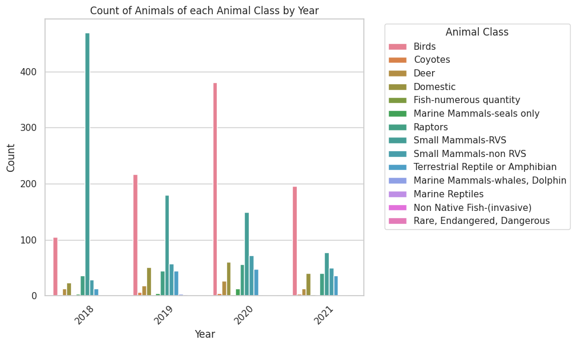

```python
# Set the style of seaborn
sns.set(style="whitegrid")

# Create the bar plot
plt.figure(figsize=(10, 6))
sns.barplot(data=animal_class_over_time, x='Report_Year', y='Animal_Count',hue='Animal Class')
plt.title('Count of Animals of each Animal Class by Year')
plt.xlabel('Year')
plt.ylabel('Count')
plt.xticks(rotation=45)  # Rotate x-axis labels for better readability
plt.legend(title='Animal Class', bbox_to_anchor=(1.05, 1), loc='upper left')
plt.tight_layout()
plt.show()
```

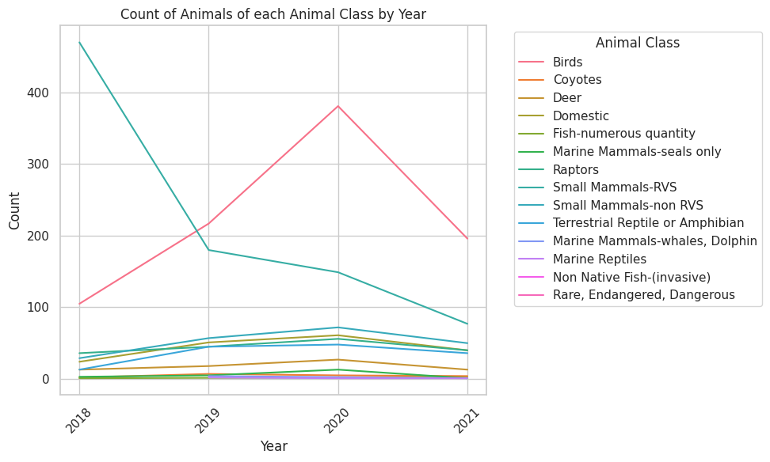

```python
# Set the style of seaborn
sns.set(style="whitegrid")

# Create the line plot
plt.figure(figsize=(10, 6))
sns.lineplot(data=animal_class_over_time, x='Report_Year', y='Animal_Count',hue='Animal Class').set_xticks(range(int(animal_class_over_time['Report_Year'].min()), int(animal_class_over_time['Report_Year'].max()) + 1))
plt.title('Count of Animals of each Animal Class by Year')
plt.xlabel('Year')
plt.ylabel('Count')
plt.xticks(rotation=45)  # Rotate x-axis labels for better readability
plt.legend(title='Animal Class', bbox_to_anchor=(1.05, 1), loc='upper left')
plt.tight_layout()
plt.show()
```

## Key Observations:

The bar plot and lineplot both titled "Count of Animals of each Animal Class by Year" shows the annual trend of different types of animals reported from 2018 to 2021. There are many trends that can be observed out of which the two main ones that I want to highlight are:

- The two most reported animal classes are "Birds" and "Small Mammals-RVS"
- The total number of "Birds" reports increased from 2018 to 2020 and drastically decreased from 2020 to 2021 whereas the total number of "Small Mammals-RVS" continuously decreased each year from 2018 to 2021.

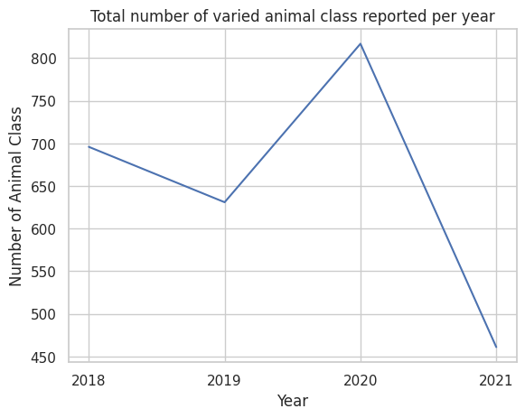

```python
final_df.groupby('Report_Year')['Animal Class'].size().plot().set_xticks(range(int(final_df['Report_Year'].min()), int(final_df['Report_Year'].max()) + 1))
plt.title("Total number of varied animal class reported per year")
plt.xlabel('Year')
plt.ylabel('Number of Animal Class')
plt.show()
```

## Summary statistics for the Animal class over time.

From the above lineplot, it is observed that the total number of animal classes reported over the years is very fluctuating. Highest animal classes were reported in the year 2020 and least in 2021.

## Question 3

How has the source of information (call source) changed over time?

```python
call_source_over_time=final_df.groupby(['Report_Year','Call Source']).size().reset_index(name='Source_Count')
call_source_over_time
```

|  | Report_Year | Call Source | Source_Count |
| --- | --- | --- | --- |
| 0 | 2018 | Central | 116 |
| 1 | 2018 | Conservancies/"Friends of" Groups | 258 |
| 2 | 2018 | Employee | 180 |
| 3 | 2018 | Observed by Ranger | 12 |
| 4 | 2018 | Other | 35 |
| 5 | 2018 | Public | 95 |
| 6 | 2019 | Central | 125 |
| 7 | 2019 | Conservancies/"Friends of" Groups | 60 |
| 8 | 2019 | Employee | 213 |
| 9 | 2019 | Observed by Ranger | 48 |
| 10 | 2019 | Other | 33 |
| 11 | 2019 | Public | 152 |
| 12 | 2020 | Central | 163 |
| 13 | 2020 | Conservancies/"Friends of" Groups | 55 |
| 14 | 2020 | Employee | 281 |
| 15 | 2020 | Observed by Ranger | 61 |
| 16 | 2020 | Other | 29 |
| 17 | 2020 | Public | 228 |
| 18 | 2021 | Central | 134 |
| 19 | 2021 | Conservancies/"Friends of" Groups | 29 |
| 20 | 2021 | Employee | 147 |
| 21 | 2021 | Observed by Ranger | 36 |
| 22 | 2021 | Other | 8 |
| 23 | 2021 | Public | 107 |

```python
call_source_pivot_table = call_source_over_time.pivot(index='Call Source', columns='Report_Year', values='Source_Count')
# Calculate the total per year
total_per_year = call_source_pivot_table.sum(axis=0)

# Append the total as a new row
call_source_pivot_table.loc['Total'] = total_per_year
call_source_pivot_table

# Define a function to highlight the total row and index
def highlight_total(s):
    is_total = s.name == 'Total'
    return ['background-color: yellow' if is_total else '' for _ in s]

# Define a function to highlight the total index
def highlight_total_index(idx):
    return ['background-color: yellow' if idx == 'Total' else '' for _ in idx]

# Style the DataFrame
styled_table = call_source_pivot_table.style.apply(highlight_total, axis=1)\
                                             .apply(lambda x: ['background-color: yellow' if x.name == 'Total' else '' for _ in x], axis=1)\
                                             .set_table_styles({'Total': [{'selector': 'th', 'props': [('background-color', 'yellow')]}]}, axis=1)

# Display the styled DataFrame
styled_table
```

| Report_Year Call Source | 2018 | 2019 | 2020 | 2021 |
| --- | --- | --- | --- | --- |
| Central | 116 | 125 | 163 | 134 |
| Conservancies/"Friends of" Groups | 258 | 60 | 55 | 29 |
| Employee | 180 | 213 | 281 | 147 |
| Observed by Ranger | 12 | 48 | 61 | 36 |
| Other | 35 | 33 | 29 | 8 |
| Public | 95 | 152 | 228 | 107 |
| Total | 696 | 631 | 817 | 461 |

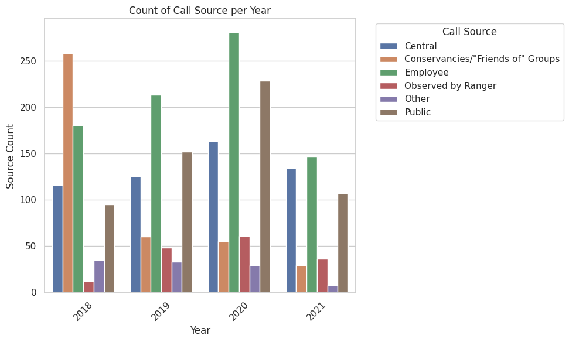

```python
# Set the style of seaborn
sns.set(style="whitegrid")

# Create the bar plot
plt.figure(figsize=(10, 6))
sns.barplot(data=call_source_over_time, x='Report_Year', y='Source_Count',hue='Call Source')
plt.title('Count of Call Source per Year')
plt.xlabel('Year')
plt.ylabel('Source Count')
plt.xticks(rotation=45)  # Rotate x-axis labels for better readability
plt.legend(title='Call Source', bbox_to_anchor=(1.05, 1), loc='upper left')
plt.tight_layout()
plt.show()
```

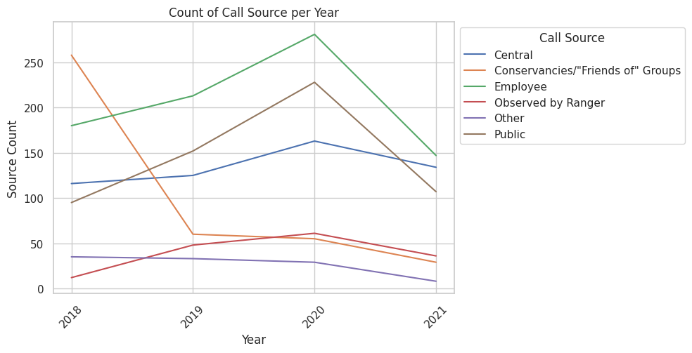

```python
# Set the style of seaborn
sns.set(style="whitegrid")

# Create the line plot
plt.figure(figsize=(10,5.2 ))
sns.lineplot(data=call_source_over_time, x='Report_Year', y='Source_Count',hue='Call Source').set_xticks(range(int(call_source_over_time['Report_Year'].min()), int(call_source_over_time['Report_Year'].max()) + 1))
plt.title('Count of Call Source per Year')
plt.xlabel('Year')
plt.ylabel('Source Count')
plt.xticks(rotation=45)  # Rotate x-axis labels for better readability
plt.legend(title='Call Source', bbox_to_anchor=(1, 1), loc='upper left')
plt.tight_layout()
plt.show()
```

## Create a publication table without table analogy

A publication table comprises information that consolidates all the answers for the 3 questions. So concatenating the above 3 pivot tables to get a publication table and storing it as a new sheet in excel file named "Publication Table Without Table Analogy".

## Note:

- This publication table is purely the result of concatenation using python code and will be saved as an excel sheet.
- There is one more sheet in the same excel file named **"Publication Table"** that has all data exactly that of present in excel sheet "Publication Table Without Table Analogy". The only difference is **"Publication Table"** is manually created as a sheet in excel and has proper formatting as per the Table Anatomy guidelines.

```python
publication_table_without_table_analogy= pd.concat([no_of_animals_pivot_table,animal_class_pivot_table,call_source_pivot_table],axis=0).reset_index()
publication_table_without_table_analogy
```

| Report_Year | index | 2018 | 2019 | 2020 | 2021 |
| --- | --- | --- | --- | --- | --- |
| 0 | ACC | 345 | 212 | 219 | 133 |
| 1 | Rehabilitator | 45 | 78 | 151 | 75 |
| 2 | Total | 390 | 290 | 370 | 208 |
| 3 | Birds | 105 | 217 | 381 | 196 |
| 4 | Coyotes | 2 | 7 | 5 | 4 |
| 5 | Deer | 13 | 18 | 27 | 13 |
| 6 | Domestic | 24 | 51 | 61 | 40 |
| 7 | Fish-numerous quantity | 1 | 0 | 2 | 2 |
| 8 | Marine Mammals-seals only | 3 | 5 | 13 | 1 |
| 9 | Marine Mammals-whales, Dolphin | 0 | 4 | 0 | 1 |
| 10 | Marine Reptiles | 0 | 2 | 1 | 1 |
| 11 | Non Native Fish-(invasive) | 0 | 0 | 1 | 0 |
| 12 | Raptors | 36 | 45 | 56 | 40 |
| 13 | Rare, Endangered, Dangerous | 0 | 0 | 1 | 0 |
| 14 | Small Mammals-RVS | 470 | 180 | 149 | 77 |
| 15 | Small Mammals-non RVS | 29 | 57 | 72 | 50 |
| 16 | Terrestrial Reptile or Amphibian | 13 | 45 | 48 | 36 |
| 17 | Total | 696 | 631 | 817 | 461 |
| 18 | Central | 116 | 125 | 163 | 134 |
| 19 | Conservancies/"Friends of" Groups | 258 | 60 | 55 | 29 |
| 20 | Employee | 180 | 213 | 281 | 147 |
| 21 | Observed by Ranger | 12 | 48 | 61 | 36 |
| 22 | Other | 35 | 33 | 29 | 8 |
| 23 | Public | 95 | 152 | 228 | 107 |
| 24 | Total | 696 | 631 | 817 | 461 |

```python
# Save the results to different sheets in an Excel file
output_file = 'Pooja_Output_File.xlsx'
with pd.ExcelWriter(output_file,mode='a') as writer:
    no_of_animals_over_time.to_excel(writer, sheet_name='Number of Animals Over Time', index=False)
    animal_class_over_time.to_excel(writer, sheet_name='Animal Types Over Time', index=False)
    call_source_over_time.to_excel(writer, sheet_name='Call Sources Over Time', index=False)
    publication_table_without_table_analogy.to_excel(writer, sheet_name='Publication Table Without Table Analogy', index=False)

print(f'Results saved to {output_file}')
```

```
Results saved to Pooja_Output_File.xlsx
```